# Explorando e Resumindo Dados: IMDB 5000 filmes

Este projeto fará uma análise dos dados do conjunto de dados [IMDB 5000 Movie Dataset](https://www.kaggle.com/carolzhangdc/imdb-5000-movie-dataset), buscando achar as principais variáveis que fazem com que o filme seja lucrativo para o estúdio que o produziu. Serão utilizados dados de filmes lançados desde os anos 20 até 2016, praticamente 100 anos na história do cinema. Fatores como orçamento, popularidade do filme, diretor e elenco no Facebook, score do filme no IMDB, quantidade de votos do filme no site IMDB, faturamento do filme e a classificação de conteúdo do filme serão usados para determinar fatores importantes na hora de definir se um filme terá lucro, terá uma boa avaliação no IMDB e até mesmo qual tipo de filmes atrai mais investimentos (orçamentos maiores).

O dataset utilizado consiste de diversas variáveis, tais como:

- movie_title: título do filme
- duration: duração do filme
- director_name: nome do diretor
- director_facebook_likes: quantidade de curtidas na página do diretor no Facebook
- actor_1_name: nome do ator principal
- actor_1_facebook_likes: quantidade de curtidas na página do ator principal no Facebook
- actor_2_name: nome de outro ator principal
- actor_2_facebook_likes: quantidade de curtidas na página do outro ator principal no Facebook
- actor_3_name: nome de outro ator principal
- actor_3_facebook_likes: quantidade de curtidas na página do outro ator principal no Facebook
- num_user_for_reviews: quantidade de avaliações no IMDB
- num_critic_for_reviews: quantidade de avaliações de críticos no IMDB
- num_voted_users: quantidade de pessoas que votou no filme
- cast_total_facebook_likes: quantidade de curtidas de todo o elenco do filme no Facebook
- movie_facebook_likes: quantidade de curtidas na página oficial do filme no Facebook
- plot_keywords: quantidade de palavras chave descrevendo o filme
- facenumber_in_poster: quantidade de atores no poster oficial
- color: cor do filme, colorido ou preto e branco
- genres: gêneros nos quais o filme se enquadra
- title_year: ano do filme
- language: idioma
- country: país onde o filme foi produzido
- content_rating: classificação do conteúdo
- aspect_ratio: proporção da tela
- movie_imdb_link: link do filme no IMDB
- gross: ganhos do filme (em dólares)
- budget: despesas do filme (em dólares)
- imdb_score: média das avaliações no IMDB

## Importando e explorando os dados

Após importar os pacotes necessários, é hora de importar e manipular o conjunto de dados do nosso projeto

```
## 'data.frame':    5043 obs. of  28 variables:
##  $ color                    : Factor w/ 3 levels ""," Black and White",..: 3 3 3 3 1 3 3 3 3 3 ...
##  $ director_name            : Factor w/ 2399 levels "","A. Raven Cruz",..: 929 801 2027 380 606 109 2030 1652 1228 554 ...
##  $ num_critic_for_reviews   : int  723 302 602 813 NA 462 392 324 635 375 ...
##  $ duration                 : int  178 169 148 164 NA 132 156 100 141 153 ...
##  $ director_facebook_likes  : int  0 563 0 22000 131 475 0 15 0 282 ...
##  $ actor_3_facebook_likes   : int  855 1000 161 23000 NA 530 4000 284 19000 10000 ...
##  $ actor_2_name             : Factor w/ 3033 levels "","50 Cent","A. Michael Baldwin",..: 1408 2218 2489 534 2433 2549 1228 801 2440 653 ...
##  $ actor_1_facebook_likes   : int  1000 40000 11000 27000 131 640 24000 799 26000 25000 ...
##  $ gross                    : int  760505847 309404152 200074175 448130642 NA 73058679 336530303 200807262 458991599 301956980 ...
##  $ genres                   : Factor w/ 914 levels "Action","Action|Adventure",..: 107 101 128 288 754 126 120 308 126 447 ...
##  $ actor_1_name             : Factor w/ 2098 levels "","50 Cent","A.J. Buckley",..: 305 983 355 1968 528 443 787 223 338 35 ...
##  $ movie_title              : Factor w/ 4917 levels "#HorrorÂ ","[Rec] 2Â ",..: 398 2731 3279 3707 3332 1961 3289 3459 399 1631 ...
##  $ num_voted_users          : int  886204 471220 275868 1144337 8 212204 383056 294810 462669 321795 ...
##  $ cast_total_facebook_likes: int  4834 48350 11700 106759 143 1873 46055 2036 92000 58753 ...
##  $ actor_3_name             : Factor w/ 3522 levels "","50 Cent","A.J. Buckley",..: 3442 1395 3134 1771 1 2714 1970 2163 3018 2941 ...
##  $ facenumber_in_poster     : int  0 0 1 0 0 1 0 1 4 3 ...
##  $ plot_keywords            : Factor w/ 4761 levels "","10 year old|dog|florida|girl|supermarket",..: 1320 4283 2076 3484 1 651 4745 29 1142 2005 ...
##  $ movie_imdb_link          : Factor w/ 4919 levels "http://www.imdb.com/title/tt0006864/?ref_=fn_tt_tt_1",..: 2965 2721 4533 3756 4918 2476 2526 2458 4546 2551 ...
##  $ num_user_for_reviews     : int  3054 1238 994 2701 NA 738 1902 387 1117 973 ...
##  $ language                 : Factor w/ 48 levels "","Aboriginal",..: 13 13 13 13 1 13 13 13 13 13 ...
##  $ country                  : Factor w/ 66 levels "","Afghanistan",..: 65 65 63 65 1 65 65 65 65 63 ...
##  $ content_rating           : Factor w/ 19 levels "","Approved",..: 10 10 10 10 1 10 10 9 10 9 ...
##  $ budget                   : num  2.37e+08 3.00e+08 2.45e+08 2.50e+08 NA ...
##  $ title_year               : int  2009 2007 2015 2012 NA 2012 2007 2010 2015 2009 ...
##  $ actor_2_facebook_likes   : int  936 5000 393 23000 12 632 11000 553 21000 11000 ...
##  $ imdb_score               : num  7.9 7.1 6.8 8.5 7.1 6.6 6.2 7.8 7.5 7.5 ...
##  $ aspect_ratio             : num  1.78 2.35 2.35 2.35 NA 2.35 2.35 1.85 2.35 2.35 ...
##  $ movie_facebook_likes     : int  33000 0 85000 164000 0 24000 0 29000 118000 10000 ...
```

## MANIPULANDO E LIMPANDO DADOS

Primeiro veremos quantos dados observáveis estão duplicados.

```
## [1] 45
```

Temos 45 linhas duplicadas que serão removidas.

```
## [1] 4998
```

Todos os títulos dos filmes ficaram com um Â ao seu final que devem ser removidos. OBS: este output será ocultado por gerar um texto muito longo e de pouco valor para a análise.

Agora, vamos achar as dados nulos do nosso dataset.

```
##                     color             director_name
##                         0                         0
##    num_critic_for_reviews                  duration
##                        49                        15
##   director_facebook_likes    actor_3_facebook_likes
##                      1000                       112
##              actor_2_name    actor_1_facebook_likes
##                         0                        33
##                     gross                    genres
##                       874                         0
##              actor_1_name               movie_title
##                         0                         0
##           num_voted_users cast_total_facebook_likes
##                         0                        33
##              actor_3_name      facenumber_in_poster
##                         0                      2149
##             plot_keywords           movie_imdb_link
##                         0                         0
##      num_user_for_reviews                  language
##                        21                         0
##                   country            content_rating
##                         0                         0
##                    budget                title_year
##                       487                       107
##    actor_2_facebook_likes                imdb_score
##                        68                         0
##              aspect_ratio      movie_facebook_likes
##                       327                      2162
```

```
## [1] 3857
```

Ainda há uma boa quantidade de filmes para ser analisada. As demais variáveis com valores nulos serão ignoradas, ou terão seus valores substituídos pela média da coluna.

Ainda falta ajustar a classificação de conteúdo dos filmes de modo que sejam mais atuais, algumas contidas no dataset não são mais utilizadas, além disso, valores nulos/em branco serão substituídos pela classificação mais popular, visto que não temos uma média que possa ser usada.

```
##
##            Approved         G        GP         M     NC-17 Not Rated
##        51        17        91         1         2         6        42
##    Passed        PG     PG-13         R     TV-14      TV-G     TV-MA
##         3       573      1314      1723         0         0         0
##     TV-PG      TV-Y     TV-Y7   Unrated         X
##         0         0         0        24        10
```

51 filmes possuem valores em branco, que serão considerados como valores nulos

```
##
##     G NC-17    PG PG-13     R
##    91    16   576  1314  1860
```

- G: todas as idades permitidas
- PG: pais devem acompanhar crianças
- PG-13: pais devem acompanhar crianças de até 13 anos
- R: pais devem acompanhar adolescentes de até 17 anos
- NC-17: não recomendado para menores de 17 anos

Variáveis como o idioma e o país poderão ser importantes para determinar o lucro e a avaliação no IMDB dos filmes? Vamos analisar!

```
##
##            Aboriginal     Arabic    Aramaic    Bosnian  Cantonese
##          3          2          1          1          1          8
##    Chinese      Czech     Danish       Dari      Dutch   Dzongkha
##          0          1          3          2          3          1
##    English   Filipino     French     German      Greek     Hebrew
##       3674          1         37         13          0          3
##      Hindi  Hungarian  Icelandic Indonesian    Italian   Japanese
##         10          1          1          2          7         12
##    Kannada     Kazakh     Korean   Mandarin       Maya  Mongolian
##          0          1          5         14          1          1
##       None  Norwegian    Panjabi    Persian     Polish Portuguese
##          1          4          0          3          0          5
##   Romanian    Russian  Slovenian    Spanish    Swahili    Swedish
##          1          1          0         26          0          1
##      Tamil     Telugu       Thai       Urdu Vietnamese       Zulu
##          0          1          3          0          1          1
```

Praticamente todos os filmes do dataset são em inglês, logo, o idioma do filme não será uma variável relevante a tentar relacionar com o lucro e com o IMDB rating.

```
##
##                               Afghanistan            Argentina
##                    0                    1                    3
##                Aruba            Australia              Bahamas
##                    1                   41                    0
##              Belgium               Brazil             Bulgaria
##                    2                    5                    0
##             Cambodia             Cameroon               Canada
##                    0                    0                   64
##                Chile                China             Colombia
##                    1                   14                    1
##       Czech Republic              Denmark   Dominican Republic
##                    3                    9                    0
##                Egypt              Finland               France
##                    0                    1                  106
##              Georgia              Germany               Greece
##                    1                   81                    1
##            Hong Kong              Hungary              Iceland
##                   13                    2                    2
##                India            Indonesia                 Iran
##                   14                    1                    4
##              Ireland               Israel                Italy
##                    7                    3                   11
##                Japan                Kenya           Kyrgyzstan
##                   17                    0                    0
##                Libya               Mexico          Netherlands
##                    0                   11                    3
##             New Line          New Zealand              Nigeria
##                    1                   11                    0
##               Norway        Official site             Pakistan
##                    4                    1                    0
##               Panama                 Peru          Philippines
##                    0                    1                    1
##               Poland              Romania               Russia
##                    1                    2                    3
##             Slovakia             Slovenia         South Africa
##                    0                    0                    3
##          South Korea         Soviet Union                Spain
##                    9                    0                   22
##               Sweden          Switzerland               Taiwan
##                    1                    0                    2
##             Thailand               Turkey                   UK
##                    4                    0                  320
## United Arab Emirates                  USA         West Germany
##                    0                 3047                    1
```

Novamente, a praticamente todos os filmes foram produzidos nos Estados Unidos, e em segundo lugar no Reino Unido. A amostragem que temos dos outros países é muito pequena, logo, o país não será uma variável a ser analisada também.

O último passo da nossa manipulação de dados será criar a variável lucro (profit) e com isso excluir a variável gross (ganhos)

Agora nossos dados estão limpos e ajustados. Além disso, nosso dataset foi simplificado para que a análise ficasse mais clara.

```
## 'data.frame':    3857 obs. of  12 variables:
##  $ director_name            : Factor w/ 2399 levels "","A. Raven Cruz",..: 929 801 2027 380 109 2030 1652 1228 554 2394 ...
##  $ duration                 : num  178 169 148 164 132 156 100 141 153 183 ...
##  $ director_facebook_likes  : num  949 563 949 22000 475 949 15 949 282 949 ...
##  $ movie_title              : chr  "Avatar " "Pirates of the Caribbean: At World's End " "Spectre " "The Dark Knight Rises " ...
##  $ num_voted_users          : num  886204 471220 275868 1144337 212204 ...
##  $ cast_total_facebook_likes: num  4834 48350 11700 106759 1873 ...
##  $ content_rating           : Factor w/ 5 levels "G","NC-17","PG",..: 4 4 4 4 4 4 3 4 3 4 ...
##  $ budget                   : num  2.37e+08 3.00e+08 2.45e+08 2.50e+08 2.64e+08 ...
##  $ title_year               : num  2009 2007 2015 2012 2012 ...
##  $ imdb_score               : num  7.9 7.1 6.8 8.5 6.6 6.2 7.8 7.5 7.5 6.9 ...
##  $ movie_facebook_likes     : num  33000 16720 85000 164000 24000 ...
##  $ profit                   : num  5.24e+08 9.40e+06 -4.49e+07 1.98e+08 -1.91e+08 ...
```

## DETERMINANDO UMA QUANTIDADE MÍNIMA DE REVIEWS

Nossa análise deverá estabelecer uma quantidade mínima votos para que o filme entre nela.

```
##    Min. 1st Qu.  Median    Mean 3rd Qu.    Max.
##       5   17261   50389  102318  123940 1689764
```

```
## [1] 1929
```

# ANÁLISE UNIVARIADA

Não será uma variável utilizada para prever o imdb rating ou buscar uma correlação com as demais variáveis, mas vamos analisar a quantidade de filmes lançados por ano no nosso conunto de dados a título de curiosidade

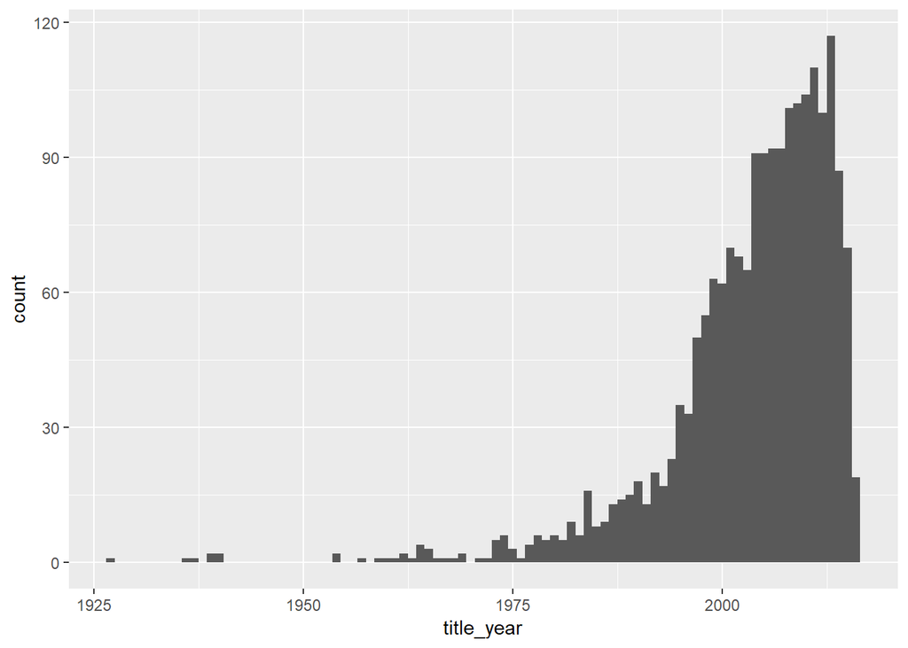

Há uma quantidade muito maior de filmes lançados a partir a década de 90 nos nossos dados. Todavia, o ano de lançamento não será uma variável relacionada com o imdb rating.

Vamos dividir as variáveis restantes da seguinte forma: - Popularidade: director_facebook_likes, cast_total_facebook_likes, num_voted_users, movie_facebook_likes; - Outros: content_rating, duration, imdb_score; - Financeiro: profit, budget;

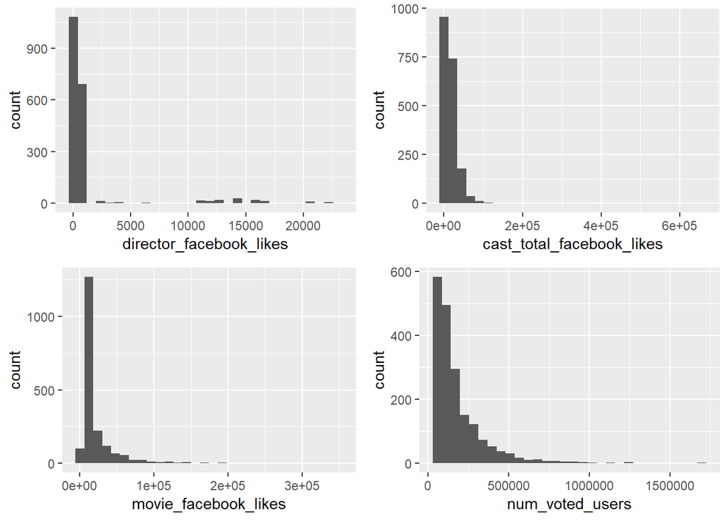

Todos os dados relacionados com a popularidade do filme apresentam uma distribuição positiva

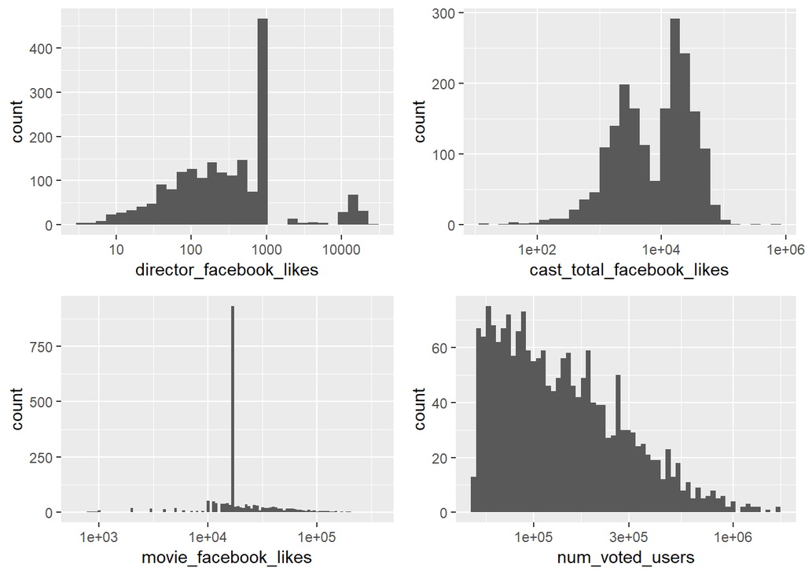

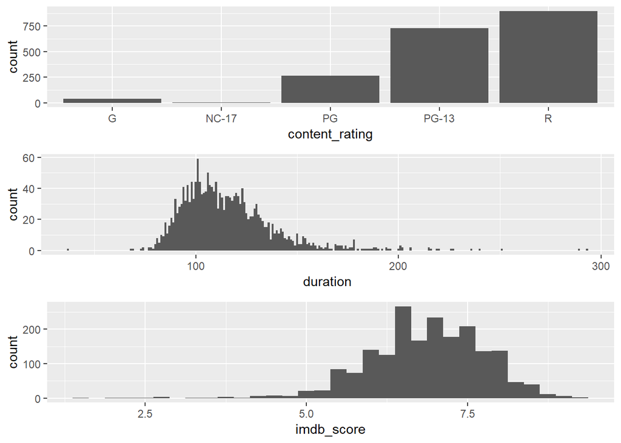

Podemos ver que há uma grande quantidade de filmes R e PG-13 comparado com as demais classificações de conteúdo. Quanto ao tempo dos filmes podemos ver que a maioria possui aproximadamente 2 horas de duração, então vamos criar um novo gráfico para filmes com duração entre 60 e 180 minutos. Poucos filmes da nossa lista possuem um IMDB score inferior a 5, também usaremos um valor mínimo de IMDB igual a 5 para criar nosso novo histograma.

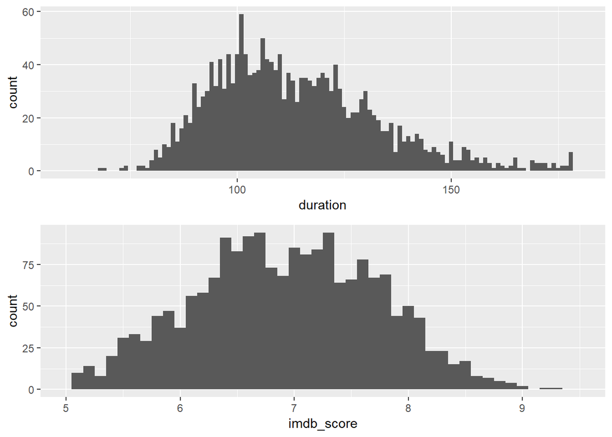

Os filtros utilizados deixaram as variáveis com uma distribuição normal, sendo assim, usaremos estes filtros de maneira definitiva para o nosso estudo.

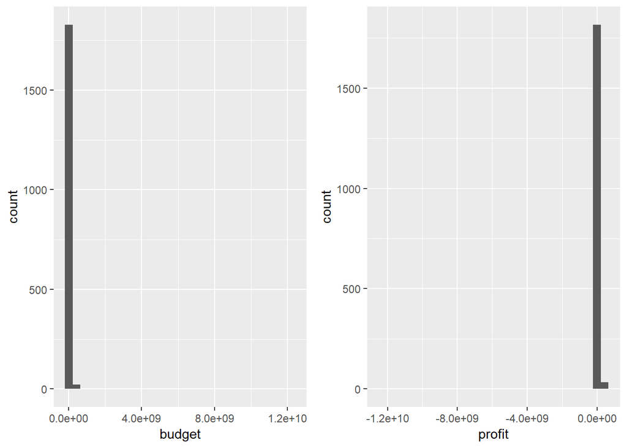

Claramente temos um problema com os valores de lucro e orçamento no dataset. Vamos determinar que os filmes do dataset não tenham orçamento superior a 350 milhões de US$.

```
##      Min.   1st Qu.    Median      Mean   3rd Qu.      Max.
##      7000  17000000  35000000  52657537  70000000 300000000
```

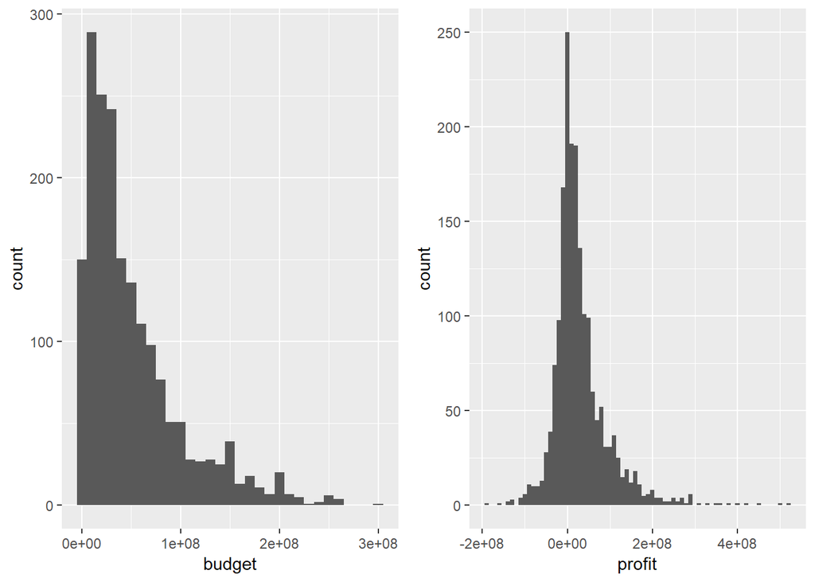

```
##       Min.    1st Qu.     Median       Mean    3rd Qu.       Max.
## -190641321   -5261308   15600000   29417410   49654900  523505847
```

Para o orçamento temos uma distribuição positiva, do tipo calda longa, enquanto para o lucro temos algo próximo a uma distribuição normal.

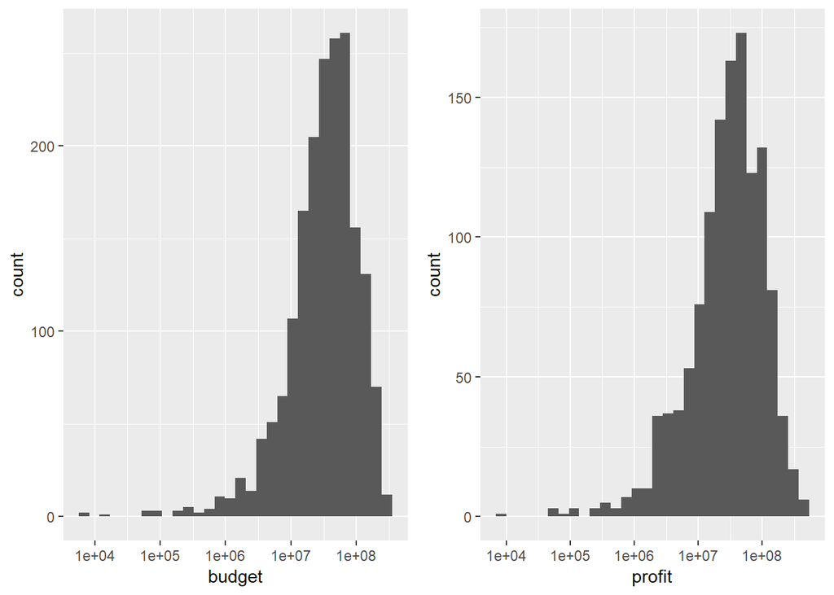

Aplicando a escala logaritimica podemos ver algo mais próximo a uma distribuição normal dos dados observados.

## ANÁLISE BIVARIADA

Vamos começar analisando a relação entre algumas variáveis.

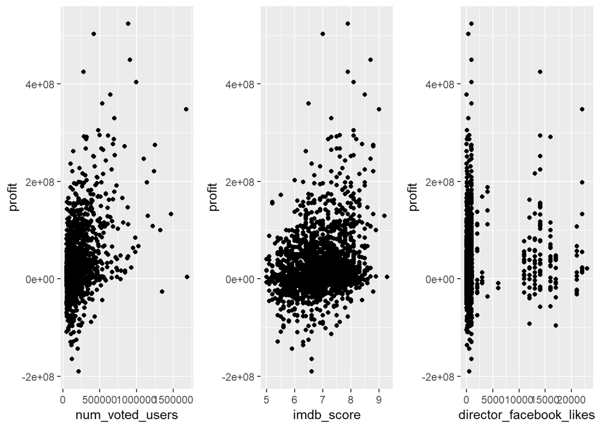

Os scatter plots confirmam uma tendência de filmes com mais votos terem um lucro maior. No entanto, as demais correlações não ficam tão evidentes, exatamente por serem mais fracas.

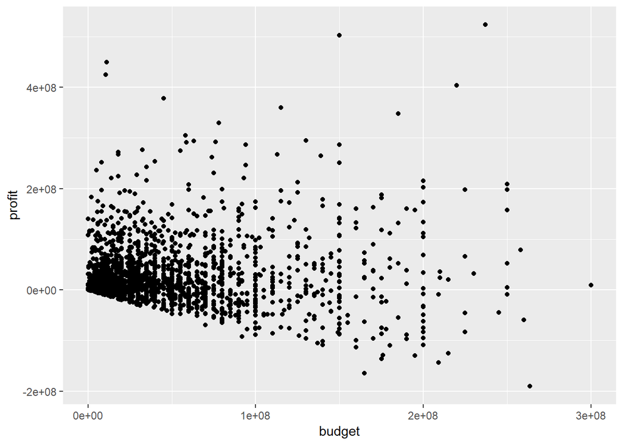

Este gráfico apresenta duas tendências: filmes caros que deram muito lucro e filmes caros que deram muito prejuízo, o que explica a correlação de praticamente 0 entre as variáveis lucro e orçamento.

## ANÁLISE MULTIVARIADA

Vamos começar a análise multivariada com uma matriz de correlações.

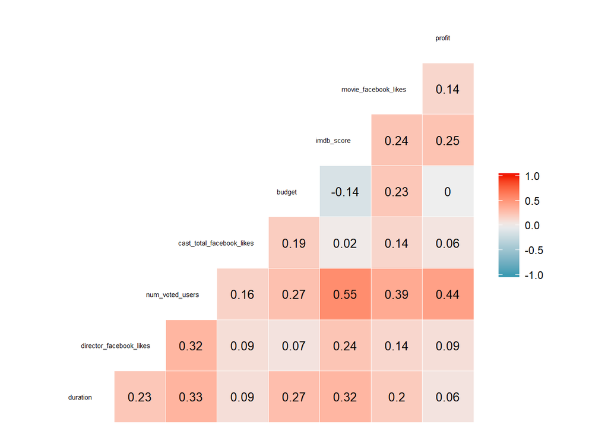

Podemos ver que a variável lucro está mais correlacionada com a quantidade de usuários que avaliaram o filme (0.44) do que com o IMDB score em si (correlação de 0.25). Além disso, podemos ver que a popularidade do filme, elenco e diretor no Facebook não são tão importantes e que o orçamento tem uma correlação bastante fraca com o lucro do filme. O imdb score apresenta uma forte correlação com a quantidade de votos do filme no site IMDB, enquanto isso podemos ver que o orçamento está mais correlacionado de forma positiva com o tempo do filme (filmes maiores podem necessitar de mais recursos, mais edição, etc.) e com a quantidade de votos do filme no IMDB.

Por fim, vamos relacionar a classificação de conteúdo com o lucro e analisar se temos alguma tendência.

Primeiro vamos determinar um ponto de corte para a variável lucro

```
##       Min.    1st Qu.     Median       Mean    3rd Qu.       Max.
## -190641321   -5261308   15600000   29417410   49654900  523505847
```

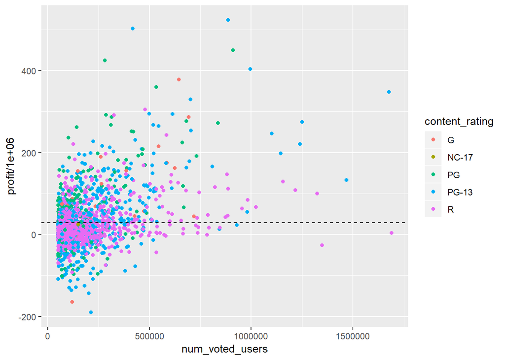

Mesmo sendo a grande maioria na nossa análise, temos poucos filmes de classificação de conteúdo R entre os mais lucrativos.

Como temos 1849 filmes na nossa análise, vamos selecionar os 20 filmes de maior valor em determinada variável (top 1%) para aprofundar nossa análise.

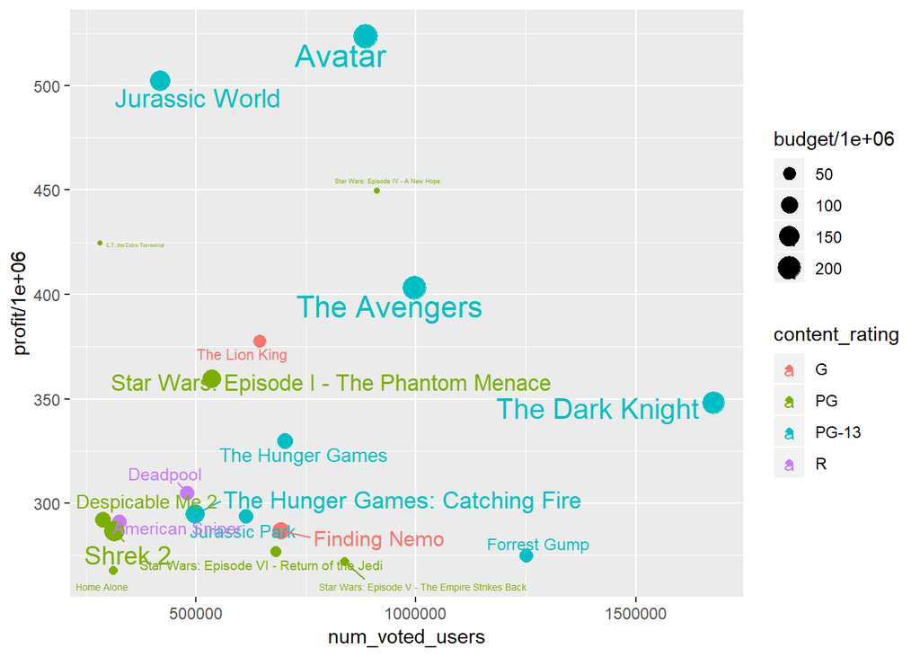

```
##    Min. 1st Qu.  Median    Mean 3rd Qu.    Max.
##   5.000   6.400   6.900   6.904   7.500   9.300
```

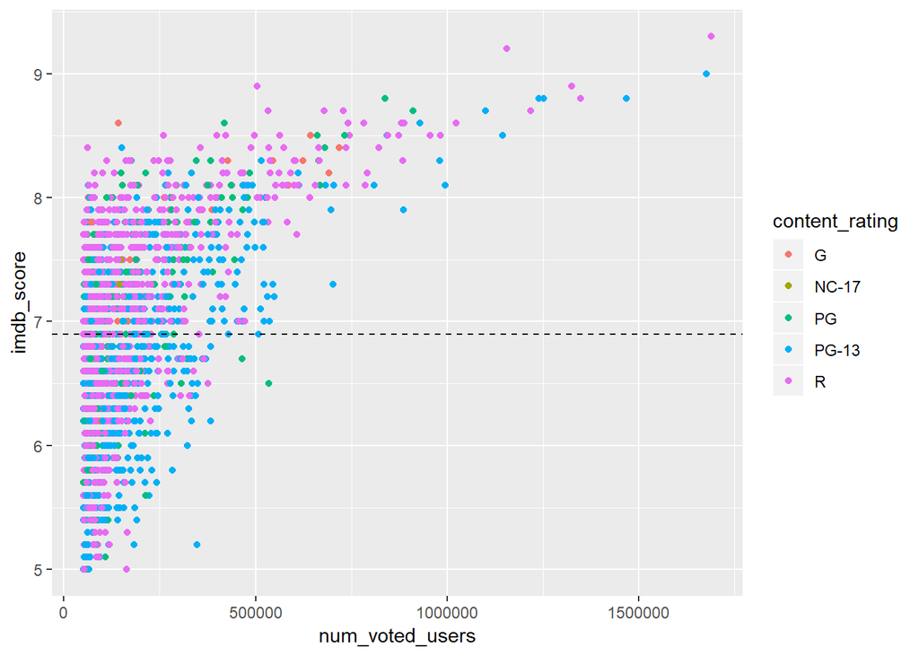

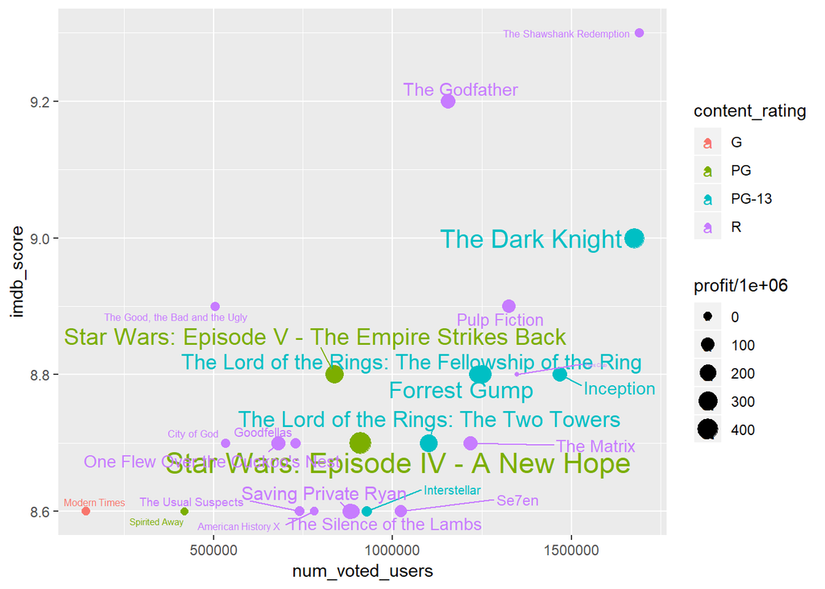

Em compensação, entre os filmes de maior imdb score podemos ver uma predominância de filmes de classificação R. Destes quatro gráficos podemos tirar o seguinte: - Filmes mais populares tendem a dar mais lucro e ter maior imdb score - Filmes direcionado a um público mais abrangente (PG e PG-13) obtém um maior lucro mesmo tendo um menor imdb score - Filmes de classificação de conteúdo R tendem a ter um imdb score superior aos demais

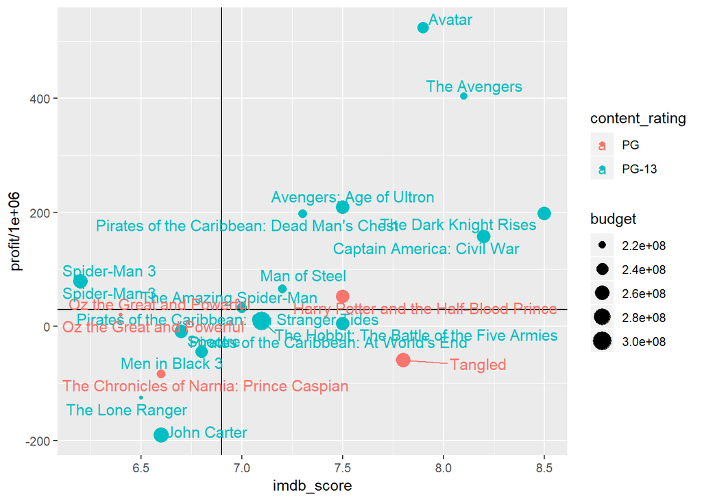

Ao analisarmos os 20 filmes mais caros podemos segmentá-los em 4 grupos distindos: - Filmes que ficaram abaixo da média geral de lucro e imdb score - Filmes que ficarama abaixo da média em apenas um dos requisitos (lucro ou imdb score) - Filmes que ficaram acima da média em ambas as variáveis

## GRÁFICOS FINAIS

### Primeiro Gráfico

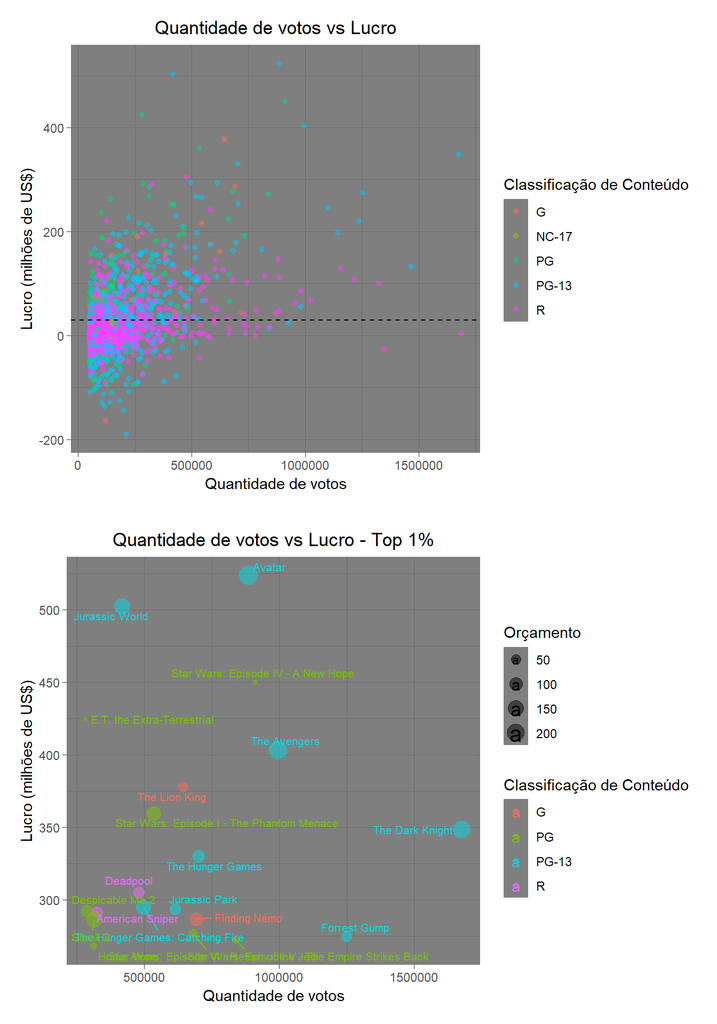

### Segundo Gráfico

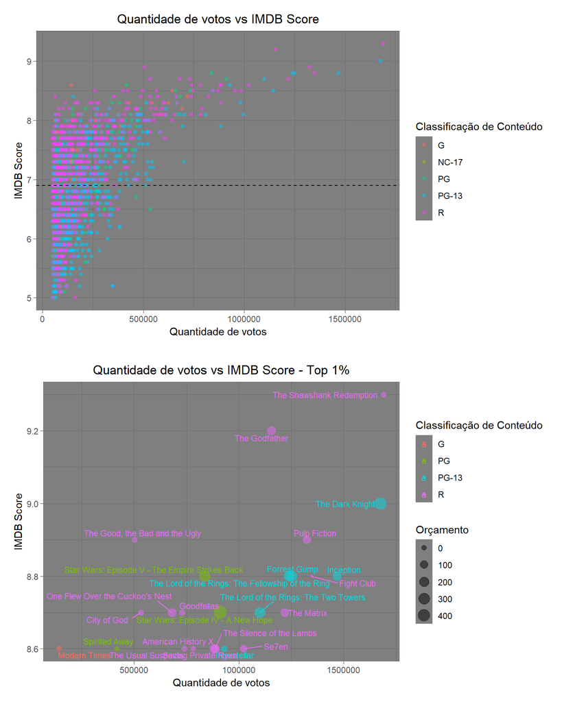

### Terceiro Gráfico

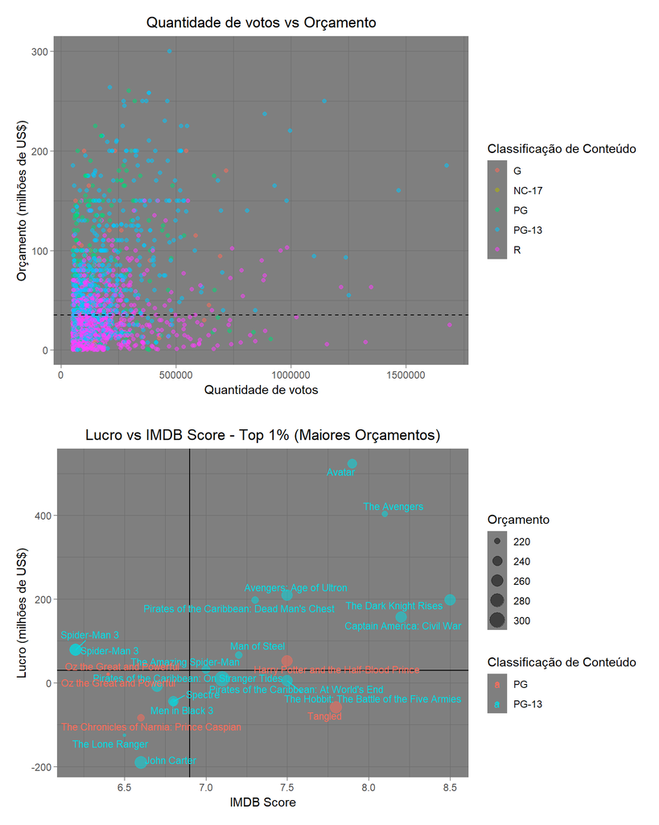

### Discussão sobre o Terceiro Gráfico

Assim como geram maiores lucros, filmes de classificação de conteúdo familiar tendem a receber maiores investimentos. Muitos filmes recebem menores investimentos por terem uma classificação de conteúdo para pessoas mais velhas, e muitos deles acabam tendo um caráter independente e não são produzidos por grandes estúdios, gerando orçamentos menores. Entre os 20 maiores orçamentos temos apenas filmes de classificação PG e PG-13, e fazendo um comparativo entre Orçamento vs Lucro vs IMDB Score, podemos perceber que pelo menos metade destes filmes ficaram abaixo da média no que diz repeito a lucro ou aceitação da crítica (imdb score). Entre os filmes mais caros, os maiores lucros foram gerados por Avatar, Vingadores, Vingadores: Era de Ultron, Piratas do Caribe, Capitão América: Guerra Civil e O Cavaleiro das Trevas Ressurge, da triologia Batman dirigida por Christopher Nolan. Entre os mais caros, o filme que melhor agregou lucro e aceitação da crítica foi Vingadores, com um lucro superior a 400 milhões e um IMDB Score superior a 8!

## REFLEXÃO

O projeto apresentou algumas dificuldades na sua execução pelo fato da plataforma Kaggle conter poucos datasets referentes a filmes, este que escolhi parece ser o mais completo, apesar de conter alguns dados que precisaram ser limpos. Após a limpeza dos dados o gráfico da matriz de correlações me ajudou a dar um norte para a minha pesquisa, percebendo que a quantidade de votos era uma variável bastante importante. A análise multivariada, usando cores para segmentar os filmes quanto à classificação de conteúdo foi fundamental para perceber um comportamento do público e indústria do cinema: filmes de caráter mais familiar e roteiro mais simples tendem a movimentar mais dinheiro, enquanto filmes mais complexos e com cenas mais fortes tendem a receber maior aclamação da crítica. Seria interessante que este dataset contivesse filmes mais recentes, mas considerei a amostragem satisfatória. Além disso o índice Metacritics e Rotten Tomatoes poderia tornar a análise mais aprofundada. A quantidade de prêmios/indicações dos filmes também seria uma variável interessante de ser analisada. Com isso, concluo minha análise e creio que os gráficos finais gerados respondem algumas perguntas importantes e ajudam a encontrar um padrão na indústria cinematográfica.